# Лабораторная работа №3

Markdown

Липатников Андрей

1032253853@rudn.ru

Российский университет дружбы народов

# Информация

## Докладчик

- Липатников Андрей
- Студент Российского университета дружбы народов им. П. Лумумбы
- 1032253853@rudn.ru

# Вводная часть

## Актуальность

- Markdown — стандарт де-факто для технической документации
- Исходник читается без специального ПО и хранится в git
- Один исходник — три формата: pdf, docx, md
- Все последующие отчёты курса готовятся именно в Markdown

## Объект и предмет исследования

- **Объект**: процесс подготовки отчётных документов в формате Markdown
- **Предмет**: оформление отчёта по лабораторной работе №2 на основе предоставленного шаблона Quarto
- **Критерий результата**: отчёт, собранный в форматы pdf, docx и md, загруженный в репозиторий GitHub

## Цели и задачи

- Цель:
  - Научиться оформлять отчёты с помощью легковесного языка разметки Markdown.
- Задачи:
  - Подготовить отчёт по лабораторной работе №2 на основе предоставленного шаблона qmd.
  - Собрать отчёт в форматы pdf, docx и md и перенести файлы из `_output`.
  - Зафиксировать и загрузить изменения в репозиторий GitHub (add, commit, push).

# Материалы и методы

## Используемое ПО и среда

- **Среда**: Fedora 41 (Sway) в VirtualBox (настроена в лабораторной работе №1)
- **Инструменты**:
  - Quarto — система сборки документации
  - Pandoc — конвертация Markdown в целевые форматы
  - Git и GitHub — хранение и публикация
- **Исходные материалы**: шаблон отчёта qmd, проектный конфигурационный файл

## Методика выполнения

- Заполнение шаблона qmd содержанием отчёта по лабораторной работе №2
- Сборка отчёта командой рендера Quarto
- Перенос собранных файлов из выходного каталога `_output`
- Публикация через git: add, commit, push

# Содержание исследования

## Исходное состояние и шаблон отчёта

- Папка report изначально содержит шаблонные файлы и каталог `image`
- Предоставленный шаблон qmd соответствует структуре ГОСТ 7.32-2001

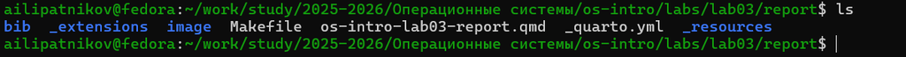

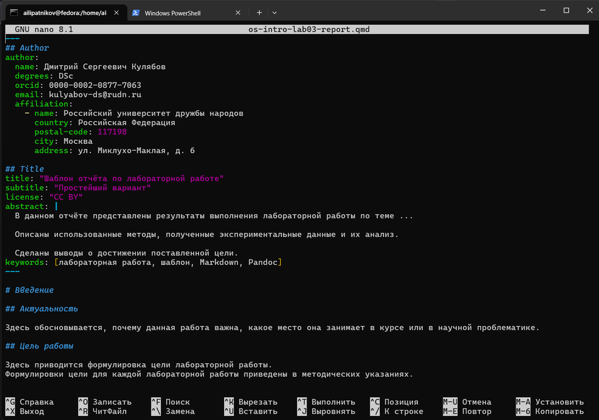

## Заполнение отчёта по шаблону

- В шаблон внесено содержание отчёта по лабораторной работе №2 (Git)
- Установка git и gh, SSH- и GPG-ключи, подпись коммитов, рабочее пространство

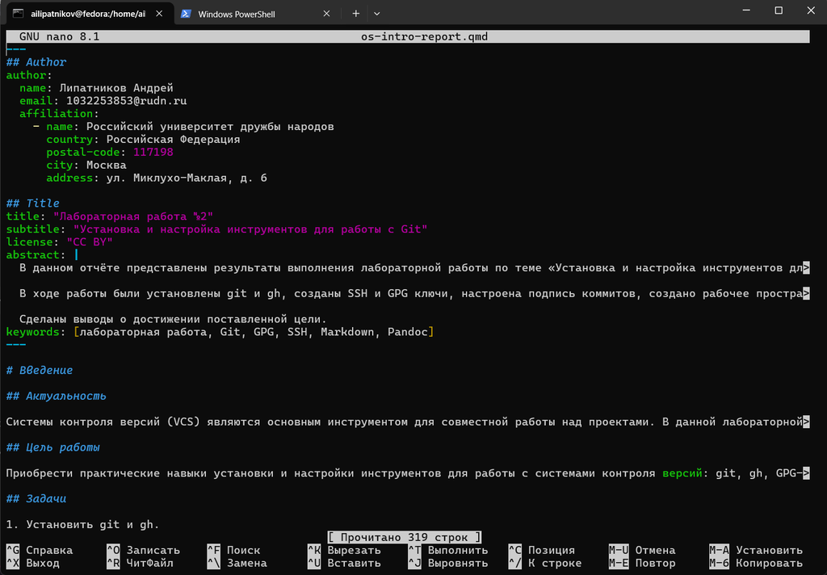

## Скрипт сборки

- Проектный конфигурационный файл задаёт форматы вывода, стили и параметры конвертации

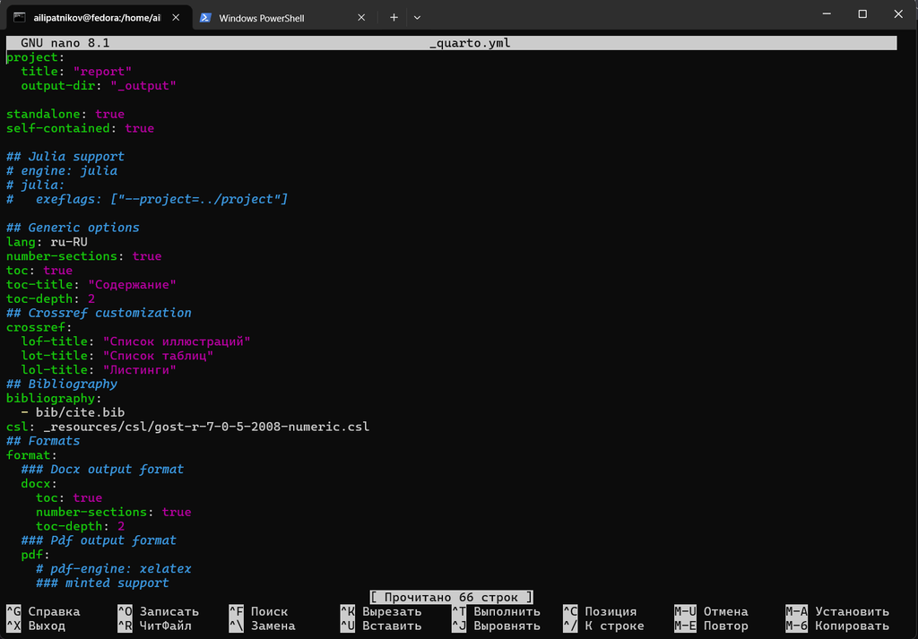

## Сборка и перенос файлов

- Отчёт собран командой рендера
- Файлы из `_output` перенесены в рабочий каталог

[figure not shown]

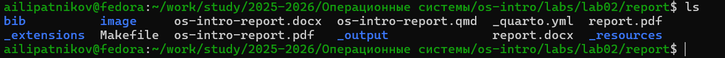

## Публикация в репозиторий

- Изменения добавлены в индекс, зафиксированы и отправлены на GitHub

[figure not shown]

# Результаты

## Полученные результаты

[output not shown]

- Изменения загружены в репозиторий GitHub

# Заключение

## Главный вывод

Освоен автоматизированный цикл подготовки отчётов: один исходник в Markdown — сборка в pdf, docx и md одной командой — публикация через git. Навык применим ко всем последующим отчётам курса.